# Picture This: Applied Practice Datasets

Jamison Crawford, MPA

Institutional Researcher, The Graduate School

January 29, 2020

# 1 Welcome

Welcome to **Picture This: Applied Practice in Data Visualization**.

This page contains a host of materials for practicing data visualization, including:

- Links to the original presentation
- Thirteen preprocessed datasets for applied practice
- Dataset documentation to explore and understand your data
- Resources for color, accessibility, and other tools to polish your viz
- Tutorials to learn about and connect your data to *Google Data Studio* & *MS Excel*

# 2 Presentation

Click **here** to download Tuesday’s presentation, **Picture This: Best Practices in Data Visualization**.

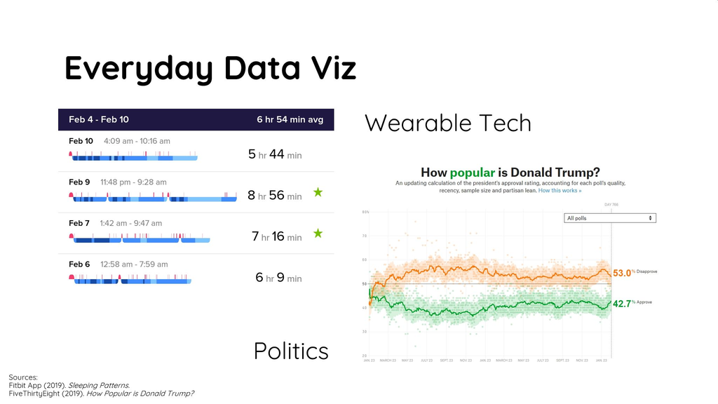

Recall the main takeaways from Tuesday’s presentation:

- **You’re already an expert** (i.e. *you know what looks good*).
- **You’re always persuading** (i.e. *every chart is manipulative*).
- **Respect your audience** (i.e. *their intelligence, time,* etc.).
  - Use the **best “data ink”** and limit eye movement
  - Rely on **conventions** (e.g. *“up” is “North”, “green” is “good”*)
  - Lose the **junk** (i.e. *ink should only aid understanding*)
  - Add **polish** (i.e. *spend 5-10 extra minutes on a viz*)

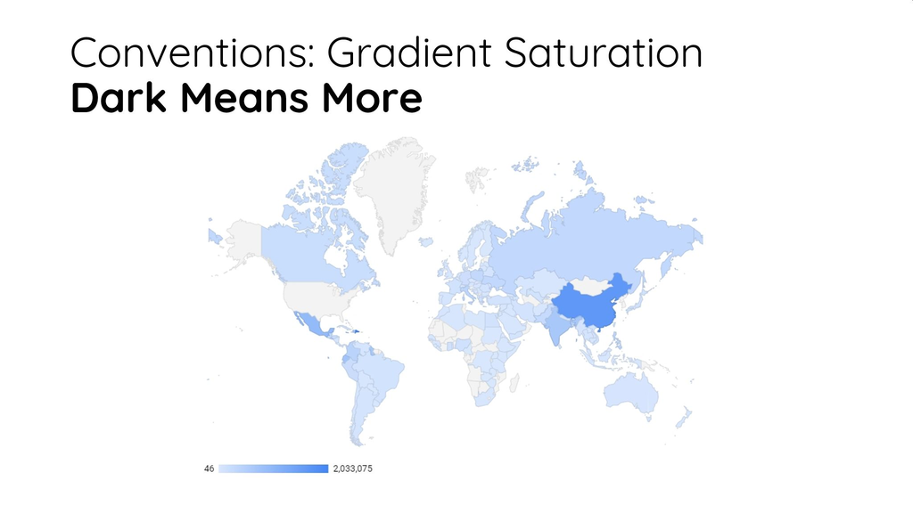

You can view the code to process our practice datasets and write this page by visiting the [**GitHub repository**](https://github.com/jamisoncrawford/dataviz).

Lastly, click [**here**](https://drive.google.com/file/d/1BO26j7VmWmxhk9cg1AChaIGSrITJp5C8/view) to view the handout on choosing the best visualization tooling.

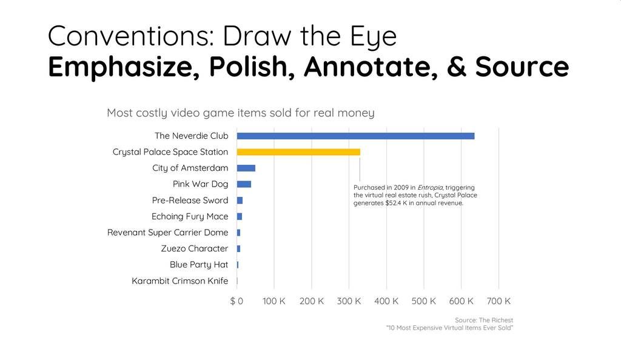

# 3 Practice Datasets

Feel free to use your own data or peruse the available practice datasets and documentation below.

Data were selected for their variance to support several approaches to data visualization.

Some datasets are moderately large, others are quite small, but all are clean.

- Variable names are formatted for case, punctuation, and descriptiveness
- Datetimes have been formatted to ISO format and parsed on both `Month` and `Year`
- Coordinate values are concatenated and parsed for all possible longitude-latitude permutations

**It’s up to you to find the stories in the data.**

## 3.1 Mammalian Sleep Patterns

**Total Observations:** 83

**Total Variables:** 11

**Recommended Stories:** Comparisons

Sleep patterns of 83 mammals, including their common name, genus, diet, total sleep state, REM state, and awake state (in hours), as well as body and brain weight.

View the documentation [**here**](https://ggplot2.tidyverse.org/reference/msleep.html).

| Mammal | Genus | Vore | Order | Status | Total Sleep | REM | Cycle |
| --- | --- | --- | --- | --- | --- | --- | --- |
| Arctic fox | Vulpes | Carnivore | Carnivora |  | 12.5 |  |  |
| Bottle-nosed dolphin | Tursiops | Carnivore | Cetacea |  | 5.2 |  |  |
| Caspian seal | Phoca | Carnivore | Carnivora | VU | 3.5 | 0.4 |  |
| Cheetah | Acinonyx | Carnivore | Carnivora | LC | 12.1 |  |  |
| Common porpoise | Phocoena | Carnivore | Cetacea | VU | 5.6 |  |  |

Open it [**here**](https://docs.google.com/spreadsheets/d/1NzqHZzynywgZMbBj7qKD7tsNpG4f5xLmETVq2Q_hDXo/edit?usp=sharing) in *Google Sheets* to copy and connect it to *Google Data Studio* or download as a .CSV.

## 3.2 U.S. Economics

**Total Observations:** 574

**Total Variables:** 6

**Recommended Stories:** Timeseries

Historical data on economic indicators in the United States from 1967 to 2015, including total population, personal savings rates, personal consumption expenditures, unemployment rates, and median unemployment duration (in weeks).

View the documentation [**here**](https://ggplot2.tidyverse.org/reference/economics.html).

| Date | Year | Month | Population | Consumption | Savings | Duration | Unemployed |
| --- | --- | --- | --- | --- | --- | --- | --- |
| 1967-07-01 | 1967 | July | 198,712,000 | $506,700,000,000 | 12.6 | 4.5 | 2,944,000 |
| 1967-08-01 | 1967 | August | 198,911,000 | $509,800,000,000 | 12.6 | 4.7 | 2,945,000 |
| 1967-09-01 | 1967 | September | 199,113,000 | $515,600,000,000 | 11.9 | 4.6 | 2,958,000 |
| 1967-10-01 | 1967 | October | 199,311,000 | $512,200,000,000 | 12.9 | 4.9 | 3,143,000 |
| 1967-11-01 | 1967 | November | 199,498,000 | $517,400,000,000 | 12.8 | 4.7 | 3,066,000 |

Open it [**here**](https://docs.google.com/spreadsheets/d/1T0LdBMRgdXpflUgphL2W3gkxdAQ-UT6GYDNPSYjCts0/edit?usp=sharing) in *Google Sheets* to copy and connect it to *Google Data Studio* or download as a .CSV.

## 3.3 Australian Wine

**Total Observations:** 176

**Total Variables:** 6

**Recommended Stories:** Timeseries

Historical data on monthly wine sales in Australia by total bottles from 1980 to 1994.

View the documentation [**here**](https://cran.r-project.org/web/packages/forecast/forecast.pdf) (pp. 137-138).

| Year | Month | Date | Year & Month | Year & Month (ISO) | Bottles |
| --- | --- | --- | --- | --- | --- |
| 1980 | January | 1980-01-01 | 1980, January | 1980-01 | 15,136 |
| 1980 | February | 1980-02-01 | 1980, February | 1980-02 | 16,733 |
| 1980 | March | 1980-03-01 | 1980, March | 1980-03 | 20,016 |
| 1980 | April | 1980-04-01 | 1980, April | 1980-04 | 17,708 |
| 1980 | May | 1980-05-01 | 1980, May | 1980-05 | 18,019 |

Open it [**here**](https://docs.google.com/spreadsheets/d/16XjLjj0ZiHP-NAMC19qztf_YEttLK17fIdCL12Ep6EI/edit?usp=sharing) in *Google Sheets* to copy and connect it to *Google Data Studio* or download as a .CSV.

## 3.4 Houston Crime

**Total Observations:** 86,314

**Total Variables:** 19

**Recommended Stories:** Geospatial, Timeseries

Dates and times of violent crimes reported in Houston, Texas, including census blocks, cop beats, and longitude-latitude coordinates.

View the documentation [**here**](https://www.houstontx.gov/police/cs/Monthly_Crime_Data_by_Street_and_Police_Beat.htm).

| Date | Offense | Street | Day | Longitude | Latitude |
| --- | --- | --- | --- | --- | --- |
| 2010-01-01 | Murder | Marlive | Friday | -95.4373883 | 29.6779015 |
| 2010-01-01 | Robbery | Telephone | Friday | -95.2988769 | 29.6917121 |
| 2010-01-01 | Aggravated Assault | Wickview | Friday | -95.455864 | 29.5992174 |
| 2010-01-01 | Aggravated Assault | Ashland | Friday | -95.4033373 | 29.7902425 |
| 2010-01-01 | Aggravated Assault | Canyon | Friday | -95.3779081 | 29.6706341 |

Open it [**here**](https://docs.google.com/spreadsheets/d/1oIY6q8JqUnRalvX3Qv6XpF8h7Mxkh270AY7ugRsq7Uc/edit?usp=sharing) in *Google Sheets* to copy and connect it to *Google Data Studio*.

This is a big table! If you’re only using *Microsoft Excel*, click [**here**](https://github.com/jamisoncrawford/dataviz/raw/master/Applied%20Practice%20Content/data/houston.csv) to directly download as .CSV.

## 3.5 Anderson’s Irises

**Total Observations:** 150

**Total Variables:** 6

**Recommended Stories:** Comparisons

Edgar Anderson’s 150 samples of three unique species of Iris flowers, including Setosa, Versicolor, and Virginica, as well as the dimensions of their petals and sepals.

View the documentation [**here**](https://www.rdocumentation.org/packages/datasets/versions/3.6.2/topics/iris).

| Iris | Species | Sepal Length | Sepal Width | Petal Length | Petal Width |
| --- | --- | --- | --- | --- | --- |
| 1 | Setosa | 5.1 | 3.5 | 1.4 | 0.2 |
| 2 | Setosa | 4.9 | 3.0 | 1.4 | 0.2 |
| 3 | Setosa | 4.7 | 3.2 | 1.3 | 0.2 |
| 4 | Setosa | 4.6 | 3.1 | 1.5 | 0.2 |
| 5 | Setosa | 5.0 | 3.6 | 1.4 | 0.2 |

Open it [**here**](https://docs.google.com/spreadsheets/d/1qHnBa7hHoxidn8F5AHaOzygSf1LUK7rc4fxkF3H294U/edit?usp=sharing) in *Google Sheets* to copy and connect it to *Google Data Studio* or download as a .CSV.

## 3.6 College Score Cards

**Total Observations:** 7,112

**Total Variables:** 21

**Recommended Stories:** Geospatial & Timeseries

Reduced from 1,978 variables, the U.S. Department of Education’s College Score Cards contain key data points on post-secondary institutions, including ACT and SAT scores, admissions rates, total undergrads, tuition revenue, and average faculty salaries, as well as longitude-latitude coordinates.

View the documentation [**here**](https://collegescorecard.ed.gov/data/documentation/).

Find the data portal [**here**](https://collegescorecard.ed.gov/data/).

| ID | Institution | City | State | Longitude | Latitude |
| --- | --- | --- | --- | --- | --- |
| 100654 | Alabama A & M University | Normal | AL | -86.568502 | 34.783368 |
| 100663 | University of Alabama at Birmingham | Birmingham | AL | -86.799345 | 33.505697 |
| 100690 | Amridge University | Montgomery | AL | -86.17401 | 32.362609 |
| 100706 | University of Alabama in Huntsville | Huntsville | AL | -86.640449 | 34.724557 |
| 100724 | Alabama State University | Montgomery | AL | -86.295677 | 32.364317 |

Open it [**here**](https://docs.google.com/spreadsheets/d/16Z_S25YUDTA9XTETiP3erHlgWfo2m8Ues_jWCax0pHE/edit?usp=sharing) in *Google Sheets* to copy and connect it to *Google Data Studio*.

This is a big table! If you’re only using *Microsoft Excel*, click [**here**](https://github.com/jamisoncrawford/dataviz/raw/master/Applied%20Practice%20Content/data/college.csv) to directly download as .CSV.

## 3.7 Australian Wool

**Total Observations:** 119

**Total Variables:** 3

**Recommended Stories:** Timeseries

Quarterly woolen yarn sales in tons from 1965 to 1994.

View the documentation [**here**](https://cran.r-project.org/web/packages/forecast/forecast.pdf) (pp. 138).

| Year | Quarter | Tons |
| --- | --- | --- |
| 1965 | 1 | 6,172 |
| 1965 | 2 | 6,709 |
| 1965 | 3 | 6,633 |
| 1965 | 4 | 6,660 |
| 1966 | 1 | 6,786 |

Open it [**here**](https://docs.google.com/spreadsheets/d/1ZqMtPkW7cOyGFj-pxx0oEB5rm62mRCQ-gfCLNqCAmWg/edit?usp=sharing) in *Google Sheets* to copy and connect it to *Google Data Studio* or download as a .CSV.

## 3.8 Fuel Efficiency

**Total Observations:** 234

**Total Variables:** 11

**Recommended Stories:** Comparisons

Comparison data on the fuel economy of 38 popular cars from 1999 and 2008, including make, model, engine displacement, cylinders, transmission type, class, and city/highway mileage.

View the documentation [**here**](https://ggplot2.tidyverse.org/reference/mpg.html).

| Make | Model | Year | Cylinders | Transmission | City | Highway |
| --- | --- | --- | --- | --- | --- | --- |
| Audi | A4 | 1999 | 4 | Manual | 18 | 29 |
| Audi | A4 | 1999 | 4 | Manual | 21 | 29 |
| Audi | A4 | 2008 | 4 | Manual | 20 | 31 |
| Audi | A4 | 2008 | 4 | Manual | 21 | 30 |
| Audi | A4 | 1999 | 6 | Manual | 16 | 26 |

Open it [**here**](https://docs.google.com/spreadsheets/d/1V4-57hFM-ghCwZ1UUG-of3IPwjINaJTl-WQ6n9Oo_Jo/edit?usp=sharing) in *Google Sheets* to copy and connect it to *Google Data Studio* or download as a .CSV.

## 3.9 53,000 Diamonds

**Total Observations:** 53,940

**Total Variables:** 9

**Recommended Stories:** Comparisons

A massive set of 53,940 diamonds measured in carats, length, width, and depth dimensions, and professionally-assessed color, cut, and clarity.

View the documentation [**here**](https://ggplot2.tidyverse.org/reference/diamonds.html).

| Cut | Carats | Color | Clarity | Price (USD) | Length | Width | Depth |
| --- | --- | --- | --- | --- | --- | --- | --- |
| Ideal | 3.50 | H | I1 | $12,587 | 9.65 | 9.59 | 6.03 |
| Ideal | 3.22 | I | I1 | $12,545 | 9.49 | 9.42 | 5.92 |
| Ideal | 3.01 | J | SI2 | $16,037 | 9.25 | 9.20 | 5.69 |
| Ideal | 3.01 | J | I1 | $16,538 | 8.99 | 8.93 | 5.86 |
| Ideal | 2.75 | D | I1 | $13,156 | 9.04 | 8.98 | 5.49 |

Open it [**here**](https://docs.google.com/spreadsheets/d/1sVh_xUnnwuB-AQzkgRMKN8TZyHPyR4dQTklDHTgD9qg/edit?usp=sharing) in *Google Sheets* to copy and connect it to *Google Data Studio*.

This is a big table! If you’re only using *Microsoft Excel*, click [**here**](https://github.com/jamisoncrawford/dataviz/raw/master/Applied%20Practice%20Content/data/rocks.csv) to directly download as .CSV.

## 3.10 Texas Real Estate

**Total Observations:** 8,602

**Total Variables:** 11

**Recommended Stories:** Comparisons, Geospatial, Timeseries

Historical data on Texas real estate sales from 2000 to 2015, including city, state, date of sale, total sales, total value (USD), median price, and estimated duration to sell all listed properties.

View the documentation [**here**](https://ggplot2.tidyverse.org/reference/txhousing.html)

| Year | City | State | Month | Total Sales | Total Value | Median Price |
| --- | --- | --- | --- | --- | --- | --- |
| 2000 | Abilene | Texas | January | 72 | $5,380,000 | $71,400 |
| 2000 | Abilene | Texas | February | 98 | $6,505,000 | $58,700 |
| 2000 | Abilene | Texas | March | 130 | $9,285,000 | $58,100 |
| 2000 | Abilene | Texas | April | 98 | $9,730,000 | $68,600 |
| 2000 | Abilene | Texas | May | 141 | $10,590,000 | $67,300 |

Open it [**here**](https://docs.google.com/spreadsheets/d/1-KicsB_bJZz3ANk8mnhnUmJktzXy1AnHrXPY3OpWo6c/edit?usp=sharing) in *Google Sheets* to copy and connect it to *Google Data Studio* or download as a .CSV.

## 3.11 Daily Gold Prices

**Total Observations:** 1,108

**Total Variables:** 4

**Recommended Stories:** Timeseries

Daily morning valuations of gold in USD from 1985 to 1988.

View the documentation [**here**](https://cran.r-project.org/web/packages/forecast/forecast.pdf) (pp. 84-85).

| Date | Year | Month | USD |
| --- | --- | --- | --- |
| 1985-01-01 | 1985 | January | $306.25 |
| 1985-01-02 | 1985 | January | $299.50 |
| 1985-01-03 | 1985 | January | $303.45 |
| 1985-01-04 | 1985 | January | $296.75 |
| 1985-01-05 | 1985 | January | $304.40 |

Open it [**here**](https://docs.google.com/spreadsheets/d/16HB4s8wtGmry1IHQw9giNFi0N2bNZX0CucjwEDNUWUo/edit?usp=sharing) in *Google Sheets* to copy and connect it to *Google Data Studio* or download as a .CSV.

## 3.12 Chick Weights

**Total Observations:** 71

**Total Variables:** 3

**Recommended Stories:** Comparisons

Experiment results from randomly assigning, newborn chicks to different diets, like soybean and meatmeal, and measuring their weight.

View the documentation [**here**](https://stat.ethz.ch/R-manual/R-patched/library/datasets/html/chickwts.html).

| Chick | Feed Group | Grams |
| --- | --- | --- |
| 1 | Horsebean | 179 |
| 2 | Horsebean | 160 |
| 3 | Horsebean | 136 |
| 4 | Horsebean | 227 |
| 5 | Horsebean | 217 |

Open it [**here**](https://docs.google.com/spreadsheets/d/1K3D_KXJh2NnBsMnonNJvKoculks6Xey4dX0wa7Dgr3E/edit?usp=sharing) in *Google Sheets* to copy and connect it to *Google Data Studio* or download as a .CSV.

## 3.13 Classic Cars

**Total Observations:** 32

**Total Variables:** 12

**Recommended Stories:** Comparisons

Specs of 32 classic cars from a 1974 issue of U.S. magazine *Motor Trend*, including fuel economy, cylinders, gears, weight, engine displacement, horsepower, and transmission.

View the documentation [**here**](https://www.rdocumentation.org/packages/datasets/versions/3.6.2/topics/mtcars).

| Model | MPG | Cylinders | Displacement | Horsepower | Pounds | Transmission |
| --- | --- | --- | --- | --- | --- | --- |
| Mazda RX4 | 21.0 | 6 | 160 | 110 | 2,620 | Manual |
| Mazda RX4 Wag | 21.0 | 6 | 160 | 110 | 2,875 | Manual |
| Datsun 710 | 22.8 | 4 | 108 | 93 | 2,320 | Manual |
| Hornet 4 Drive | 21.4 | 6 | 258 | 110 | 3,215 | Automatic |
| Hornet Sportabout | 18.7 | 8 | 360 | 175 | 3,440 | Automatic |

Open it [**here**](https://docs.google.com/spreadsheets/d/1dFKlfRTnVFyuXSWcDXVyslm4AO86MJY_-1zUjevMh2A/edit?usp=sharing) in *Google Sheets* to copy and connect it to *Google Data Studio* or download as a .CSV.

# 4 Connecting to Data Studio

*Google Data Studio* is a point-and-click, drag-and-drop application for creating interactive reporting tools.

In order to create a report and connect your data, you must:

1. Sign into your *Google* account
2. Copy or upload a *Google Sheets* table to your *Google Drive*
3. Create a new report in *Google Data Studio* (with one click)
4. Select your connection application (*Google Sheets*)
5. Make sure your variables are the correct class and add your new “connection”

## 4.1 Copy an Existing Dataset

Open up a dataset in *Google Sheets*.

1. Click “File” and “Make a copy…” (see *Step 1.1*)
2. Make sure “Folder” is set to “My Drive” (see *Step 1.2*)
3. Click “OK”

**Step 1.1: Select “Make a copy…” in “File”**

[figure not shown]

**Step 1.2: Make sure “Folder” is set to “My Drive” and click “OK”**

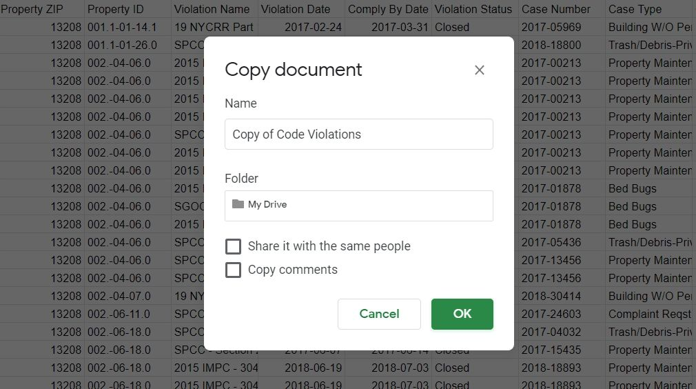

## 4.2 Create & Connect Reports

In order to create a new report and connect it to your data, visit the [**Data Studio home page**](https://datastudio.google.com/).

1. Click “Start a New Report” (see *Step 2.1*)
2. Select “Create New Data Source” (see *Step 2.2*)
3. Select your connection method (see *Step 2.3*)

**Step 2.1: Click “Start a New Report”**

[figure not shown]

**Step 2.2: Click “Create New Data Source”**

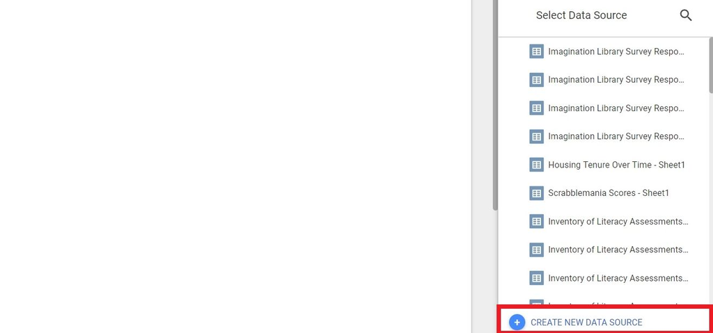

**Step 2.3: Select “Google Sheets” as your connection method**

[figure not shown]

## 4.3 Edit Your Connection

It’s the final stretch. You just have to choose your table and check your variables.

1. Select the spreadsheet, worksheet, and options from *Google Sheets* (see *Step 3.1*)
2. Click “OK”, then check that the “Type” of each variable is correct (see *Step 3.2*)
3. Click “Add to Report”

**Step 3.1: Select the correct “Spreadsheet” (B) and options (D)**

[figure not shown]

**Step 3.2: Check each variable “Type” and select “Add to Report”**

[figure not shown]

# 5 Visualization Resources

The following are just a few resources for creating effective visualizations with any tooling.

## 5.1 Choose the Best Viz

What visualization is best depends on shape and type. [**Data Viz Project**](https://datavizproject.com/) can help.

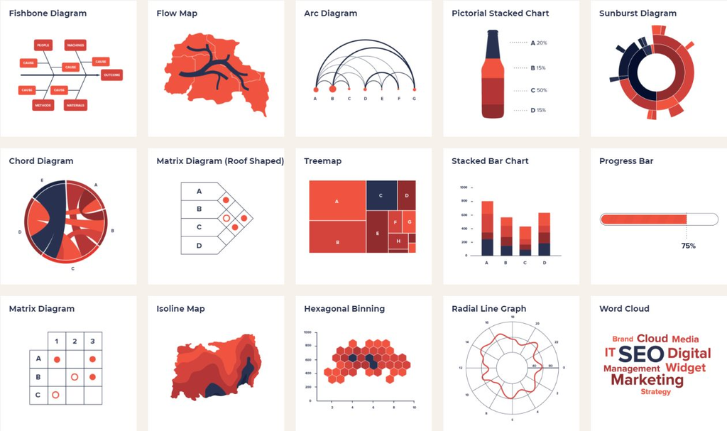

## 5.2 Extract Colors

[**HTML Color Codes**](https://html-color-codes.info/colors-from-image/) allows you to upload images and logos to extract their precise colors.

[figure not shown]

## 5.3 Generate Palettes

[**Coolers**](https://coolors.co/) is an excellent tool for generating complementary and gradient color palettes.

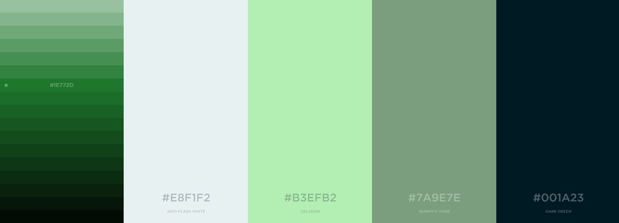

## 5.4 Mind Accessibility

If using light fonts or dark backgrounds, ensure the contrast is still visually-accessible with [**WebAIM**](https://webaim.org/resources/contrastchecker/).

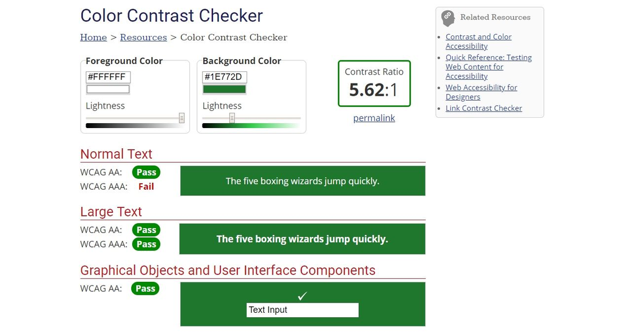

## 5.5 Use Legible Fonts

Though **Google Data Studio** fonts are limited, they’re extremely legible.

Consider downloading some font families to complement your reports and presentations in [**Google Fonts**](https://fonts.google.com/).

Tuesday’s presentation used “Quicksand” - it’s dope. You can easily look up how to install new fonts.

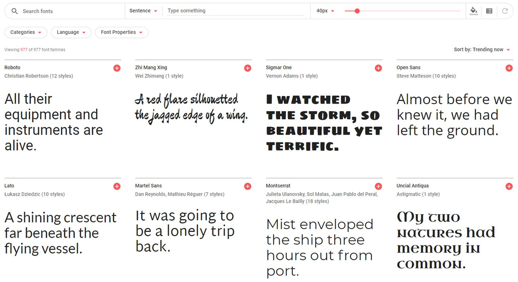

## 5.6 Additional Tutorials

I’ve created a number of more advanced guides covering *Google Data Studio*, check them out:

- [**Introduction to Google Data Studio: Creating Reports**](https://rpubs.com/JamisonCrawford/gds1)
- [**Introduction to Google Data Studio: Choropleth Maps & Color Palettes**](https://rpubs.com/JamisonCrawford/gds2)
- [**Introduction to Google Data Studio: Tables, Score Cards, & New Fields**](https://rpubs.com/JamisonCrawford/gds3)
- [**Introduction to Google Data Studio: Advanced Filtering**](https://rpubs.com/JamisonCrawford/gds4)

# 6 Contact

Feel free to contact me at any time with questions or for help.

- **Name:** Jamison Crawford, MPA
- **Email:** **jcrawford52@gsu.edu**
- **LinkedIn:** [**in/jamisoncrawford**](https://www.linkedin.com/in/jamisoncrawford/)
- **GitHub Profile:** [**github.com/jamisoncrawford**](https://github.com/jamisoncrawford)
- **Rpubs Portfolio:** [**rpubs.com/jamisoncrawford**](https://rpubs.com/jamisoncrawford)

# 7 Thanks

Thank you to everyone who’s participated in **Picture This: Best Practices in Data Visualization**.

Special thanks to **Dori Neptune** for facilitating all logistics - we couldn’t have done it without her.

Lastly, thanks to the following and their leadership for trusting me in front of an audience:

- [**Center for the Advancement of Students & Alumni (CASA)**](https://casa.gsu.edu/)
- [**The Graduate School at Georgia State University**](https://graduate.gsu.edu/)